# Huggingface Transformers

Tao Zou

2024-06-02

# Log in HuggingFace

```python
from huggingface_hub import HfFolder

hf_token = "My HuggingFace Access Tokens"
HfFolder.save_token(hf_token)
```

# AutoTokenizer

## Load a tokenizer and show its information

```python
from transformers import AutoTokenizer

model_name = "..."
tokenizer = AutoTokenizer.from_pretrained(model_name)
```

Show the special tokens of **bos_token**, **eos_token** and **pad_token**.

```python
print('bos token: ', tokenizer.bos_token)
print('eos token: ', tokenizer.eos_token)
print('pad token: ', tokenizer.pad_token)
print('bos token id: ', tokenizer.bos_token_id)
print('eos token id: ', tokenizer.eos_token_id)
print('pad token id: ', tokenizer.pad_token_id)
```

Show how to transfer between token and token id.

```python
print('The length of vocab is {}'.format(len(tokenizer.vocab)))
token_id = tokenizer.convert_tokens_to_ids('banana')
print(token_id)
token = tokenizer.convert_ids_to_tokens(7549)  # the converted token may be in encoded form, like Ġname
print(token)
```

Change the special tokens using the following code.

```python
# Either of the two lines below plays the same role, I can only use one of them.
tokenizer.pad_token = tokenizer.eos_token
tokenizer.pad_token_id = tokenizer.eos_token_id
```

## Encode text and Decode text by tokenizer()

For Llama3’s tokenizer, tokenizer will encode natural language into token ids, the format of which is shown below.

```python
text_list = ['I am from China', "You and me are best friends"]
tokenizer.padding_side = "right"
encoded_text = tokenizer(text_list, padding=True)
print(encoded_text)
'''
{
  'input_ids': [[128000, 40, 1097, 505, 5734, 128001, 128001],
                [128000, 2675, 323, 757, 527, 1888, 4885]],
  'attention_mask': [[1, 1, 1, 1, 1, 0, 0],
                     [1, 1, 1, 1, 1, 1, 1]]
}
'''
decoded_text = [tokenizer.decode(text, skip_special_tokens=True) for text in encoded_text['input_ids']]
print(decoded_text)
'''
['I am from China', 'You and me are best friends']
'''
```

- *padding*: padding on the right side of sentence.
  - `padding=True` or `padding='longest'`: pad to the longest sequence in a batch.
  - `padding='max_length'`: pad to the length specified with the *max_length*.
  - `padding=False`: no padding.

## chat template

As to DeepSeek model, it has template like this:

```python
message = [
    {'role': 'user', 'content': 'Select all data from table `student`.'},
    {'role': 'assistant', 'content': "SELECT * FROM `student`;"}
]

chat_template = tokenizer.apply_chat_template(message, add_generation_prompt=False, tokenize=False)
print(chat_template)
'''
<｜begin▁of▁sentence｜>You are an AI programming assistant, utilizing the Deepseek Coder model, developed by Deepseek Company, and you only answer questions related to computer science. For politically sensitive questions, security and privacy issues, and other non-computer science questions, you will refuse to answer
### Instruction:
Select all data from table `student`.
### Response:
SELECT * FROM `student`;
<|EOT|>
'''
```

- *add_generation_prompt*: add tokens at the end of messages to indicate the start of response. For example, if set `add_generation_prompt=True` there will be a new string `### Response:\n` adding to the end of the `chat_template`. But, there exist some models don’t need the special tokens before response.
- *tokenize*: whether to tokenize the entire chat template.
  - *return_tensors*: If `tokenize=True`, it is supposed to set `return_tensors='pt'` for pytorch tensor, `return_tensors='tf'` for tensorflow tensor, `return_tensors='np'` for np array.

As to Llama3 model, it doesn’t have a chat template.

```python
message = [
    {'role': 'user', 'content': 'How to print hello world?'},
    {'role': 'assistant', 'content': "What's your name?"},
    {'role': 'TKL', 'content': "My name is TKL."}

]

chat_template = tokenizer.apply_chat_template(message, tokenize=False)
print(chat_template)
'''
<|im_start|>user
How to print hello world?<|im_end|>
<|im_start|>assistant
What's your name?<|im_end|>
<|im_start|>TKL
My name is TKL.<|im_end|>
'''
```

To split the chat template into instruction part (explanatory variable) and response part (response variable). I can use the following code for DeepSeek chat template. *collator* will serve as a parameter to `SFTTrain()`.

```python
from trl import DataCollatorForCompletionOnlyLM, SFTTrainer

response_template = '### Response:'
collator = DataCollatorForCompletionOnlyLM(response_template, tokenizer=DeepSeek_tokenizer)
```

# Model

AutoModelForCausalLM

```python
from transformers import AutoModelForCausalLM

model_name = "..."
model = AutoModelForCausalLM.from_pretrained(
  model_name,
  device_map='auto',
  force_download=False,
  resume_download=True)
```

- *device_map*: which device should the parameters be loaded on. `device_map=auto` is very useful when using multi-GPUs.
- *resume_download*: if resume a previous download process.
- *force_download*: download the whole files even if some files exist。

## Download large model using huggingface-cli

```bash
pip install huggingface-hub
```

```bash
huggingface-cli login

huggingface-cli download --resume-download my/model_name --local-dir path/to/save/model
```

# Dataset

`datasets` is a python package developed by HuggingFace. It’s suggested to use `datasets` to load and prepare data when using other HuggingFace packages.

```python
from datasets import load_dataset

dataset = load_dataset('csv', data_files={
  'train': 'path/to/training_data.csv',
  'validation': 'path/to/validation_data.csv'
})

def formatting_prompt_func(dataset):
    formatted_texts = []
    # prompts and ground_truth_outputs is the only two columns of train and validation csv files.
    for i in range(len(dataset['prompts'])):
        user_message = dataset['prompts'][i]
        assistant_message = dataset['ground_truth_outputs'][i]
        message = [
            {'role': 'user', 'content': user_message},
            {'role': 'assistant', 'content': assistant_message}
        ]
        text = tokenizer.apply_chat_template(message, tokenize=False)
        formatted_texts.append(text)
    return formatted_texts
```

User-designed function `formatting_prompt_func` is used for SFT training. This function will return a list of chat templates, each one of which contains the prompt and output.

# Save

The code below shows how to save a model and its tokenizer to a folder.

```python
from transformers import AutoModelForCausalLM, AutoTokenizer

model.save_pretrained("local/model/path")
tokenizer.save_pretrained("local/model/path")

# load
model = AutoModelForCausalLM.from_pretrained("local/model/path", device='auto')
tokenizer = AutoTokenizer.from_pretrained("local/model/path")
```

# Transformer Trainer

## TrainingArguments

```python
from transformers import TrainingArguments

training_args = TrainingArguments(
  output_dir="path/to/folder",
  learning_rate=1e-5,
  per_device_train_batch_size=32,
  per_device_eval_batch_size=32,
  num_train_epochs=2,
  weight_decay=0.01,

  bf16=True,

  evaluation_strategy="epoch",
  save_strategy="epoch",
  load_best_model_at_end=True
)
```

- *evaluation_strategy*:
  - `evaluation_strategy=“no”`:
  - `evaluation_strategy="steps"`: Evaluation is done every *eval_steps*. *eval_steps*(int or float in [0, 1): the number of update steps or the ratio of total training steps between two evaluations.
  - `evaluation_strategy="epoch"`: Evaluation is done at the end of each epoch.
- *save_strategy*: the checkpoint save strategy.
  - `save_stratey="no"`:
  - `save_stratey="steps"`: Save is done every *save_steps*. *save_steps* is similar to *eval_steps*.
  - `save_stratey="epoch"`: Save is done at the end of each epoch.
- *load_best_model_at_end*(True, False): Whether or not to load the best model found during training at the end of training.
  - `load_best_model_at_end=True`: *save_strategy* needs to be the same as *evaluation_strategy*. When they are set to “steps”, *save_steps* must be a round multiple of *eval_steps*.

## Trainer

```python
from transformers import Trainer

trainer = Trainer(
  model=model,
  args=training_args,
  train_dataset=,
  eval_dataset=,
  tokenizer=tokenizer,
  data_collator=,
  compute_metrics=
)
```

# PEFT

## LoRA

The parameter updating formula is shown below:

$$\boldsymbol{W}\leftarrow\boldsymbol{W}+\alpha\cdot\boldsymbol{B}_{d\times
r}\boldsymbol{A}_{r\times d}$$

```python
from peft import LoraConfig, TaskType

peft_config = LoraConfig(
    task_type=TaskType.CAUSAL_LM,
    inference_mode=False,
    r=64,
    lora_alpha=32,
    use_rslora=True,
    lora_dropout=0.1,
    target_modules=[
        "q_proj",
        "v_proj",
        "k_proj",
        "o_proj",
        "gate_proj",
        "up_proj",
        "down_proj",
        "lm_head"
    ]
)
```

The code above aims to fine-tune a Llama structure LLM.

- *task_type*: `task_type=TaskType.CAUSAL_LM` is ok for Llama-based LLM, such as DeepSeek, CodeQwen and Llama3.
- *inference_mode*:
- *r*: the $r$ in above formula.
- *lora_alpha*: the $\alpha$ in above formula.
- *use_rslora*: if `use_rslora=True`, $\alpha$ will be replaced by $\frac{\alpha}{\sqrt{r}}$. Otherwise, $\alpha$ will be replaced by $\frac{\alpha}{r}$.

## SFT Training

Run the following code, the fine-tuning process will begin.

```python
from transformers import TrainingArguments
from trl import SFTTrainer

training_arguments = TrainingArguments(
    output_dir="peft/output_dir",
    overwrite_output_dir=True,
    num_train_epochs=1,
    load_best_model_at_end=True,
    per_device_train_batch_size=2,
    per_device_eval_batch_size=2,
    gradient_accumulation_steps=16,
    evaluation_strategy="steps", eval_steps=0.15,
    max_grad_norm = 0.3,
    auto_find_batch_size = False,
    save_total_limit = 3,
    save_steps=50,
    logging_steps=10,
    learning_rate=1e-5,
    weight_decay=0.01,
    bf16=True,
    warmup_ratio=0.01,
    group_by_length=True,
    lr_scheduler_type="cosine",
    report_to="wandb",
    neftune_noise_alpha= 5
)

trainer = SFTTrainer(
    model=model,
    peft_config=peft_config,
    train_dataset=dataset['train'],
    eval_dataset=dataset['validation'],
    formatting_func=formatting_prompt_func,
    data_collator=collator,
    tokenizer=tokenizer,
    args=training_arguments,
    max_seq_length=2100,
    packing=False
)

trainer.train()
trainer.model.save_pretrained(peft_output_dir)
```

# Model Inference

Model preparation

```python
tokenizer = ...
model = ...
device = 'cuda' if torch.cuda.is_available() else 'cpu'
model.to(device)
```

Inference per batch(**The following code needs to be inspected. It seems that different model requires different inference method.**)

```python
model.eval()

for i, (batch, _) in enumerate(val_loader):
  # batch is a list of length batch_size
  inputs_batch = [tokenizer(text, return_tensor='pt') for text in batch]
  inputs = {
    'input_ids': torch.cat([input['input_ids'] for input in inputs_batch], dim=0).to(device)
    'attention_mask': torch.cat([input['attention_mask'] for input in inputs_batch], dim=0).to(device)
}
# inputs['input_ids'] shape is (batch_size, seq_length)
# inputs['attention_mask'] shape is (batch_size, seq_length)
  responses = model.generate(**inputs, max_new_tokens=512, temperature=0)
  responses = responses.detach().cpu().numpy()
  outputs = tokenizer.batch_decode(responses, skip_special_tokens=True)
  print(outputs)
```

## Generation configuration

Load, modify and save a generation configuration.

```python
from transformers import GenerationConfig

generation_config = GenerationConfig.from_pretrained('deepseek-ai/deepseek-coder-6.7b-instruct')

generation_config = GenerationConfig.from_pretrained(
    'deepseek-ai/deepseek-coder-6.7b-instruct',
    num_beams= 5,
    do_sample=True
)
print(generation_config)
'''
GenerationConfig {
  "bos_token_id": 32013,
  "do_sample": true,
  "eos_token_id": 32021,
  "num_beams": 5
}
'''

generation_config.save_pretrained("./saved_model/", config_file_name="my_generation_config.json")
```

Create a generation configuration.

```python
generation_config = GenerationConfig(num_beams=5, do_sample=True)
```

Use my generation configuration for `model.generate()`.

```python
responses = model.generate(**inputs, generation_config=generation_config)
```

## StoppingCriteria

```python
from transformers import StoppingCriteria


class EosListStoppingCriteria(StoppingCriteria):
    def __init__(self, eos_sequence = [128256]):
        self.eos_sequence = eos_sequence

    def __call__(self, input_ids: torch.LongTensor, scores: torch.FloatTensor, **kwargs) -> bool:
        last_ids = input_ids[:,-len(self.eos_sequence):].tolist()
        return self.eos_sequence in last_ids
```

## Decoding Strategies

### multinomial sampling

Select the next token based on multinomial distribution. To do this, set `do_sample=True` and `num_beams=1`.

```python
outputs = model.generate(**inputs, do_sample=True, num_beams=1)
```

### Beam search

Denote:

$\vec{c}=\text{Show all samples in table students. SELECT}$

*Number of steps*: $L=4$

*Number of beams*: $2$

*Number of sequences*: $2$ (no larger than *number of beams*)

*Step score* of $X_t$ is $\ln{P(X_t|\vec{c},X_1,\cdots,X_{t-1})}$

*Total score* of $X_t$ is $\frac{1}{L^\alpha}\ln{P(X_1,\cdots,X_t|\vec{c})}=\frac{1}{L^\alpha}\sum_{i=1}^t{\ln{P(X_i|\vec{c},X_1,\cdots,X_{i-1})}}$

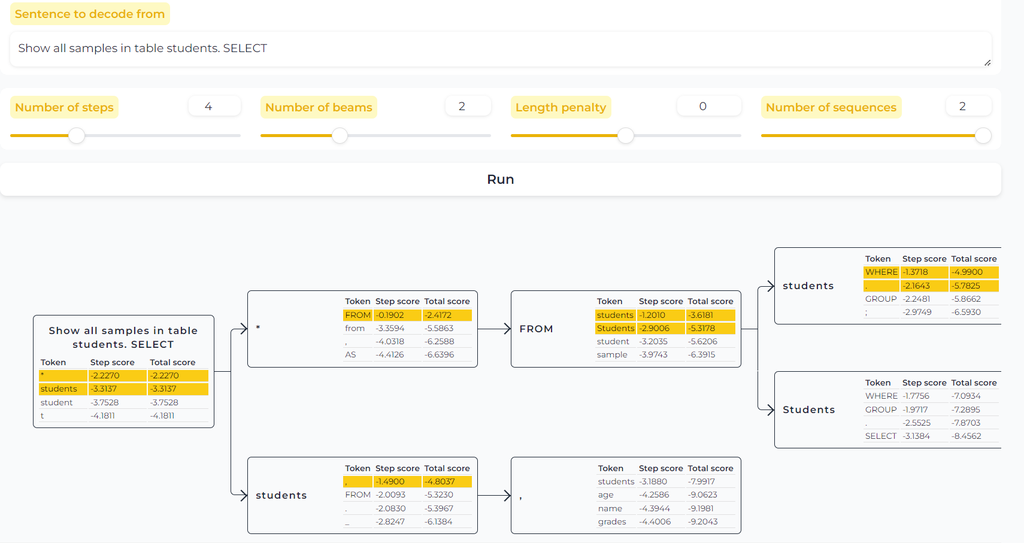

```python
model.generate(**inputs, num_beams=5)
```

## Predict by token

```python
input_text = "I want to know the top three students' name with highest grade in database student(id, name, grade). SELECT"

inputs = tokenizer(input_text, return_tensors="pt").to(device)
with torch.no_grad():
    outputs = model(**inputs)
    logits = outputs.logits  # logits shape torch.Size([1, length_of_input_text, vocab_size])
last_token_logits = logits[:, -1, :] # torch.Size([1, 128256]) the discrete distribution of the next token
top1_token_id = torch.argmax(last_token_logits, dim=-1)
print(top1_token_id, tokenizer.convert_ids_to_tokens(top1_token_id))

input_text += tokenizer.convert_ids_to_tokens(top1_token_id)[0]
inputs = tokenizer(input_text, return_tensors="pt").to(device)
with torch.no_grad():
    outputs = model(**inputs)
    logits = outputs.logits
last_token_logits = logits[:, -1, :] # torch.Size([1, 128256])
top1_token_id = torch.argmax(last_token_logits, dim=-1)
print(top1_token_id, tokenizer.convert_ids_to_tokens(top1_token_id))
```

# Accelerate

accelerate is a distributed training framework.

```bash
pip install accelerate -i https://mirrors.huaweicloud.com/repository/pypi/simple
```

## config

### auto config

```bash
python -c "from accelerate.utils import write_basic_config; write_basic_config(mixed_precision='fp16')"

accelerate env
accelerate test
```

### config by hand

```bash
accelerate config

accelerate env
accelerate test
```

1. In which compute environment are you running? This machine
2. Which type of machine are you using? multi-GPU
3. How many different machines will you use (use more than 1 for multi-node training)?
4. What is the rank of this machine?
5. What is the IP address of the machine that will host the main process?
6. What is the port you will use to communicate with the main process?
7. Are all the machines on the same local network?
8. What rendezvous backend will you use (‘static’, ‘c10d’)?
9. Should distributed operations be checked while running for errors? This can avoid timeout issues but will be slower.
10. Do you wish to optimize your script with torch dynamo?
- Which dynamo backend would you like to use?
11. Do you want to customize the defaults sent to torch.compile?
- Which mode do you want to use?
12. Do you want the fullgraph mode or it is ok to break model into several subgraphs?
13. Do you want to enable dynamic shape tracing?
14. Do you want to use DeepSpeed?

## Accelerator

```python
from accelerate import Accelerator

accelerator = Accelerator(gradient_accumulation_steps=2)
device = accelerator.device

# prepare() method wraps PyTorch objects into proper interface for distributed training.
model, optimizer, training_dataloader, scheduler = accelerator.prepare(
  model, optimizer, training_dataloader, scheduler
)

for batch in training_dataloader:
  with accelerator.accumulate(model):
    optimizer.zero_grad()
    inputs, targets = batch
    # inputs, targets = inputs.to(device), targets.to(device)  There is no need to add this line
    outputs = model(inputs)
    loss = loss_function(outputs, targets)
    # loss.backward()  There is no need to add this line
    accelerator.backward(loss)
    optimizer.step()
    scheduler.step()
```

`Accelerator()`

- *gradient_accumulation_steps*: the gradient accumulating steps before updating the model parameters. This enables me to train on a larger batch size.

### save and load model

#### single checkpoint

```python
accelerator.wait_for_every_one()
# save_model() method will unwrap and save the model state dictionary
accelerator.save_model(model, "path/to/save/model")
```

save the model with `save_pretrained()` method so that it can be reloaded with `from_pretrained()` method.

```python
from transformers import AutoModel

unwrapped_model = accelerator.unwrap_model(model)
unwrapped_model.save_pretrained(
  "path/to/save/model",
  is_main_process=accelerator.is_main_process,
  save_function=accelerator.save
)

model = AutoModel.from_pretrained("path/to/save/model")
```

#### sharded checkpoint

```python
accelerator.wait_for_every_one()
# save_model() method will unwrap and save the model state dictionary
accelerator.save_model(model, "path/to/save/model", max_shard_size="2GB", safe_serialization=True)

# Without practice, I don't understand the code
accelerate.load_checkpoint_in_model(unwrapped_model, "path/to/folder/", device_map={"":device})
```